# Step5. STEAM analysis

Please note that some steps have been pre-run in a separate vignette to generate the permutation matrices needed and to only keep genes in the gene lists that are present in the Seurat object after QC filtering. In this vignette step we showcase how to use a MetaSpot approach with STEAM, reducing sparseness and increasing power in a Visium dataset.

# 1 Load libraries

Load the necessary libraries.

```r
library(Seurat)
library(SeuratObject)
library(dplyr)
library(MASS)
library(viridis)
library(stringr)
library(ggplot2)
library(readr)
library(STEAM)
```

# 2 Load data

Load Seurat object.

```r
se <- readRDS("data/human_brain_cortex/Seurat_objects/Metaspots_normalized.rds")
se
```

```
## An object of class Seurat
## 22762 features across 352 samples within 2 assays
## Active assay: SCT (11381 features, 3000 variable features)
##  3 layers present: counts, data, scale.data
##  1 other assay present: RNA
```

```r
head(se[[]])
```

```
##      orig.ident nCount_RNA nFeature_RNA cluster_anno nCount_SCT nFeature_SCT
## 0_0           0      33901         7186            0      33910         7186
## 0_44          0      13692         4557            0      33040         5838
## 0_5           0     109616         9879            0      34772         7454
## 0_62          0      14503         4693            0      32779         5731
## 0_19          0     109353         9863            0      34912         7371
## 0_48          0       8646         3552            0      32819         6319
```

Load ranked gene lists (here from Open Targets). Please note that it is essential for downstream analysis that the gene lists are ranked from this point forward to do empirical selection of top genetic genes.

```r
OpenTargets_SCZ_Genetic_ <- as.character(t(read.table(file = "data/OpenTargets/ranked_gene_sets/OT-MONDO_0005090-associated-targets-8_25_2025-v25_06_SCZ_genetic.csv")))
length(OpenTargets_SCZ_Genetic_)
```

```
## [1] 1363
```

# 3 Prepare data for STEAM analysis

Filter out genes not present in the Seurat object.

```r
# Extract gene names from the Seurat object
gene_names <- rownames(se)

# Remove genes not present in the Seurat object from the gene lists
OpenTargets_SCZ_Genetic_ <- unique(OpenTargets_SCZ_Genetic_[OpenTargets_SCZ_Genetic_ %in% gene_names])
length(OpenTargets_SCZ_Genetic_)
```

```
## [1] 959
```

Generate sliding window gene sets from gene lists. Select your choice of trait abbreviation (disease_abbr) and a gene list descriptive term (ot_gene_set_label). We select a window size of 50 genes, moving by 10 genes for each window.

```r
window_rank_list_SCZ_Genetic <- generate_sliding_windows(OpenTargets_SCZ_Genetic_, window_size = 50, step_size = 10, disease_abbr = "SCZ", ot_gene_set_label = "Genetic")
```

Add gene sets to a list.

```r
all_gene_sets_OpenTargets <- list(OpenTargets_SCZ_Genetic_=OpenTargets_SCZ_Genetic_)
```

Merge all gene sets into one list.

```r
all_gene_sets <- all_gene_sets_OpenTargets
all_gene_sets <- append(all_gene_sets,window_rank_list_SCZ_Genetic)
```

Calculate the average gene expression per gene list and check the percentage of genes present in the Seurat object. It is important that all genes used are present in the Seurat object, otherwise the downstream statistic assumptions are invalid.

```r
score.mat <- matrix(data = NA, nrow = length(all_gene_sets), ncol = 1, dimnames = list(names(all_gene_sets), "% of genes present"))

for (i in 1:length(all_gene_sets)) {
  genes <- unlist(all_gene_sets[i])
  score.mat[i] <- mean(genes %in% rownames(se))
  se <- AddModuleScore(se,list(genes), ctrl = 100, name = list(names(all_gene_sets[i])))
}
score.mat*100
```

```
##                          % of genes present
## OpenTargets_SCZ_Genetic_                100
## SCZ_Genetic_Rank1_                      100
## SCZ_Genetic_Rank2_                      100
## SCZ_Genetic_Rank3_                      100
## SCZ_Genetic_Rank4_                      100
## SCZ_Genetic_Rank5_                      100
## SCZ_Genetic_Rank6_                      100
## SCZ_Genetic_Rank7_                      100
## SCZ_Genetic_Rank8_                      100
## SCZ_Genetic_Rank9_                      100
## SCZ_Genetic_Rank10_                     100
## SCZ_Genetic_Rank11_                     100
## SCZ_Genetic_Rank12_                     100
## SCZ_Genetic_Rank13_                     100
## SCZ_Genetic_Rank14_                     100
## SCZ_Genetic_Rank15_                     100
## SCZ_Genetic_Rank16_                     100
## SCZ_Genetic_Rank17_                     100
## SCZ_Genetic_Rank18_                     100
## SCZ_Genetic_Rank19_                     100
## SCZ_Genetic_Rank20_                     100
## SCZ_Genetic_Rank21_                     100
## SCZ_Genetic_Rank22_                     100
## SCZ_Genetic_Rank23_                     100
## SCZ_Genetic_Rank24_                     100
## SCZ_Genetic_Rank25_                     100
## SCZ_Genetic_Rank26_                     100
## SCZ_Genetic_Rank27_                     100
## SCZ_Genetic_Rank28_                     100
## SCZ_Genetic_Rank29_                     100
## SCZ_Genetic_Rank30_                     100
## SCZ_Genetic_Rank31_                     100
## SCZ_Genetic_Rank32_                     100
## SCZ_Genetic_Rank33_                     100
## SCZ_Genetic_Rank34_                     100
## SCZ_Genetic_Rank35_                     100
## SCZ_Genetic_Rank36_                     100
## SCZ_Genetic_Rank37_                     100
## SCZ_Genetic_Rank38_                     100
```

[output cut: 38 more lines]

```
## SCZ_Genetic_Rank77_                     100
## SCZ_Genetic_Rank78_                     100
## SCZ_Genetic_Rank79_                     100
## SCZ_Genetic_Rank80_                     100
## SCZ_Genetic_Rank81_                     100
## SCZ_Genetic_Rank82_                     100
## SCZ_Genetic_Rank83_                     100
## SCZ_Genetic_Rank84_                     100
## SCZ_Genetic_Rank85_                     100
## SCZ_Genetic_Rank86_                     100
## SCZ_Genetic_Rank87_                     100
## SCZ_Genetic_Rank88_                     100
## SCZ_Genetic_Rank89_                     100
## SCZ_Genetic_Rank90_                     100
## SCZ_Genetic_Rank91_                     100
```

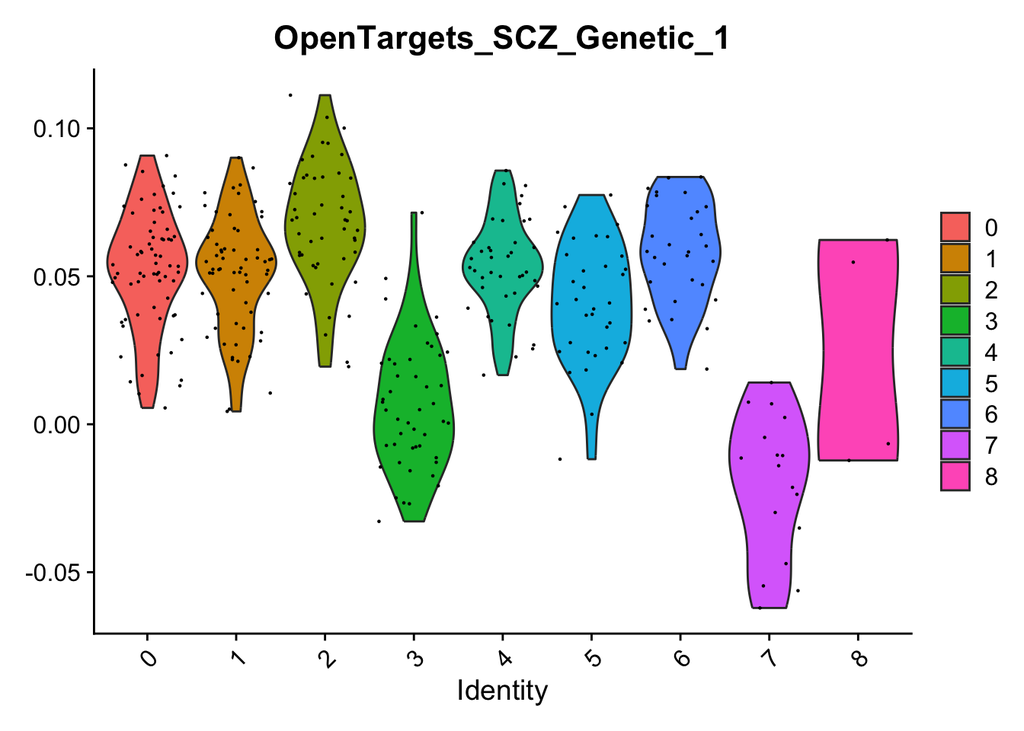

```r
VlnPlot(se, features = c("OpenTargets_SCZ_Genetic_1"), ncol = 1, group.by = "cluster_anno")
```

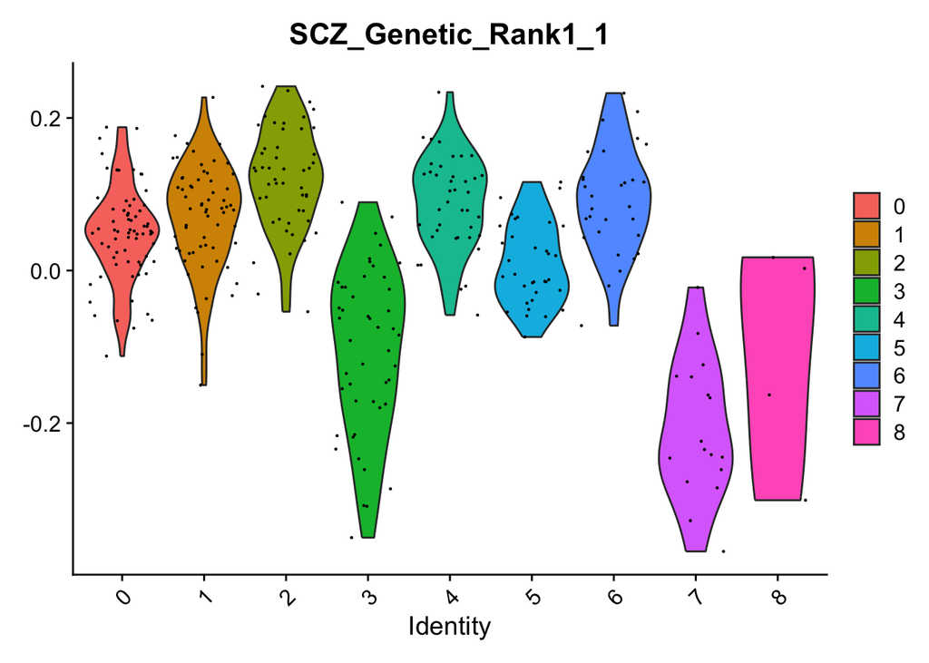

```r
VlnPlot(se, features = c("SCZ_Genetic_Rank1_1"), ncol = 1, group.by = "cluster_anno")
```

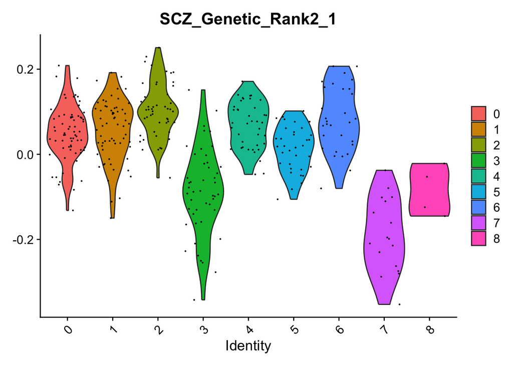

```r
VlnPlot(se, features = c("SCZ_Genetic_Rank2_1"), ncol = 1, group.by = "cluster_anno")
```

Load permutation matrices for your selected window size and genetic gene list (see separate vignette on how to generate these). OBS! Make sure that you create the Seurat object in the same way (package and filtering) when generating permutation matrices as when you run STEAM.

```r
perm_files <- c(
  "data/human_brain_cortex/permutation_matrices/perm.mat.par_p10000_g50.rds"
)

perm_matrices <- load_permutation_matrices(perm_files)
perm.mat.window.data <- as.data.frame(perm_matrices[[1]])

perm.mat.window.data[1:5,1:5]
```

```
##                     0            1            2           3           4
## Perm_nr1 -0.003798784 -0.015972330 -0.005252585  0.04971719 -0.01226212
## Perm_nr2  0.046922172  0.020985272  0.014021223 -0.01389839  0.02688441
## Perm_nr3 -0.002569286 -0.003742712 -0.006858715  0.01260132 -0.03606295
## Perm_nr4 -0.008631518 -0.026014721 -0.052324479 -0.01443105 -0.05339762
## Perm_nr5 -0.021730235 -0.001562641 -0.028174632 -0.04016470 -0.02104423
```

# 4 Empirical selection of top genetic genes

Derive an empirical threshold for top genes of a ranked gene list by comparing the ranked window gene set signal to a null gene set of equal size.

```r
 window_results.g <- window_rank_enrichment_analysis(
   se = se,
   perm.mat.window.data = perm.mat.window.data,
   window_rank_list = window_rank_list_SCZ_Genetic,
   ot_gene_set_label = "Genetic",
   disease_abbr = "SCZ",
   cluster_anno = "cluster_anno",
   imputation = "all"#,
   #log_file = "data/human_brain_cortex/log_files/log_file_pval_mat_genetic_window_SCZ.txt"
 )

head(window_results.g)
```

```
##                               cluster window median_score    p_value
## SCZ_Genetic_cluster_0_Rank1 cluster_0      1  0.050452610 0.08139186
## SCZ_Genetic_cluster_0_Rank2 cluster_0      2  0.047569724 0.08849115
## SCZ_Genetic_cluster_0_Rank3 cluster_0      3 -0.018058907 0.67743226
## SCZ_Genetic_cluster_0_Rank4 cluster_0      4 -0.022665002 0.73452655
## SCZ_Genetic_cluster_0_Rank5 cluster_0      5  0.001927471 0.41935806
## SCZ_Genetic_cluster_0_Rank6 cluster_0      6 -0.004681155 0.50444956
##                                     q05        q95 is_significant was_imputed
## SCZ_Genetic_cluster_0_Rank1 -0.04864806 0.06320936          FALSE        TRUE
## SCZ_Genetic_cluster_0_Rank2 -0.04864806 0.06320936          FALSE        TRUE
## SCZ_Genetic_cluster_0_Rank3 -0.04864806 0.06320936          FALSE        TRUE
## SCZ_Genetic_cluster_0_Rank4 -0.04864806 0.06320936          FALSE        TRUE
## SCZ_Genetic_cluster_0_Rank5 -0.04864806 0.06320936          FALSE        TRUE
## SCZ_Genetic_cluster_0_Rank6 -0.04864806 0.06320936          FALSE        TRUE
##                             imputation_type
## SCZ_Genetic_cluster_0_Rank1             all
## SCZ_Genetic_cluster_0_Rank2             all
## SCZ_Genetic_cluster_0_Rank3             all
## SCZ_Genetic_cluster_0_Rank4             all
## SCZ_Genetic_cluster_0_Rank5             all
## SCZ_Genetic_cluster_0_Rank6             all
```

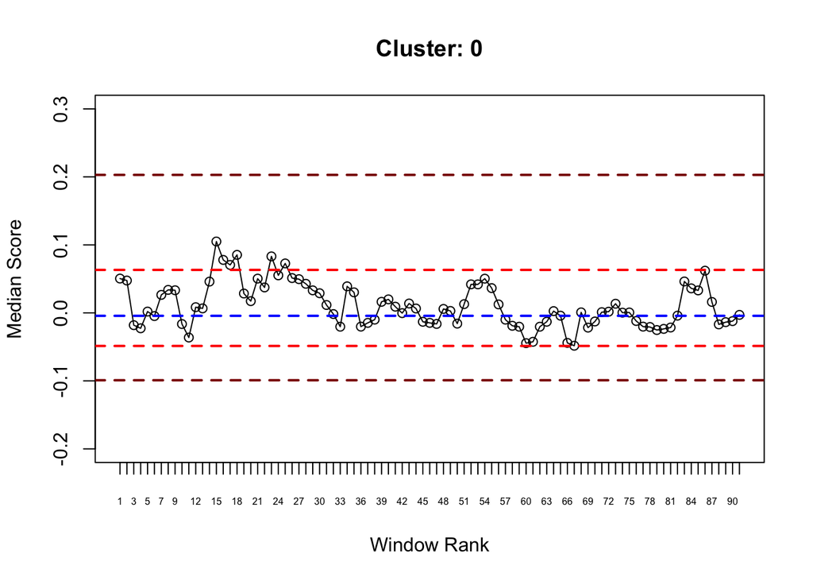

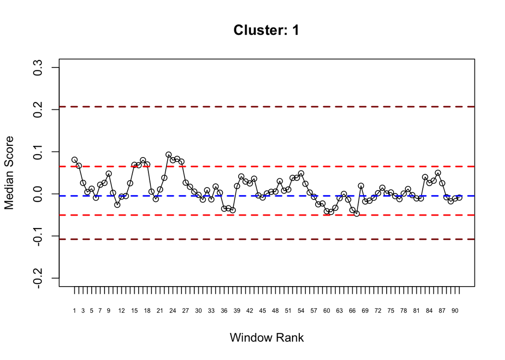

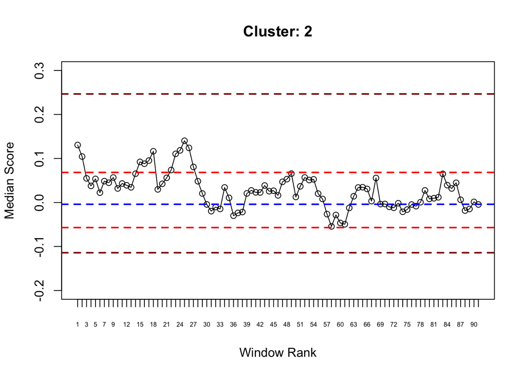

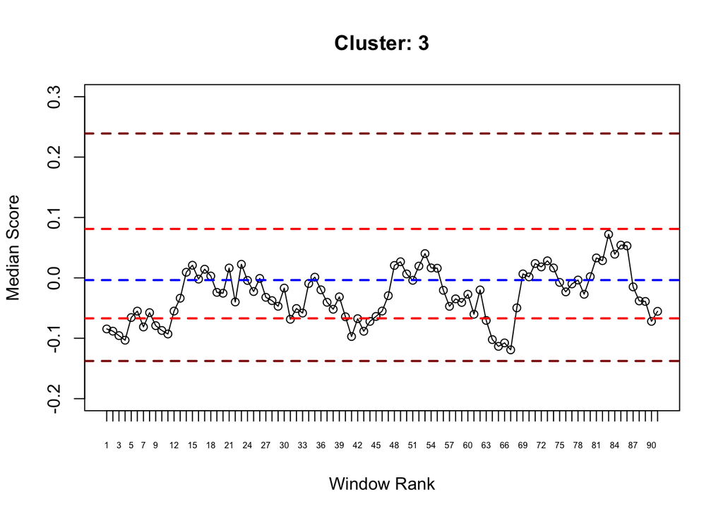

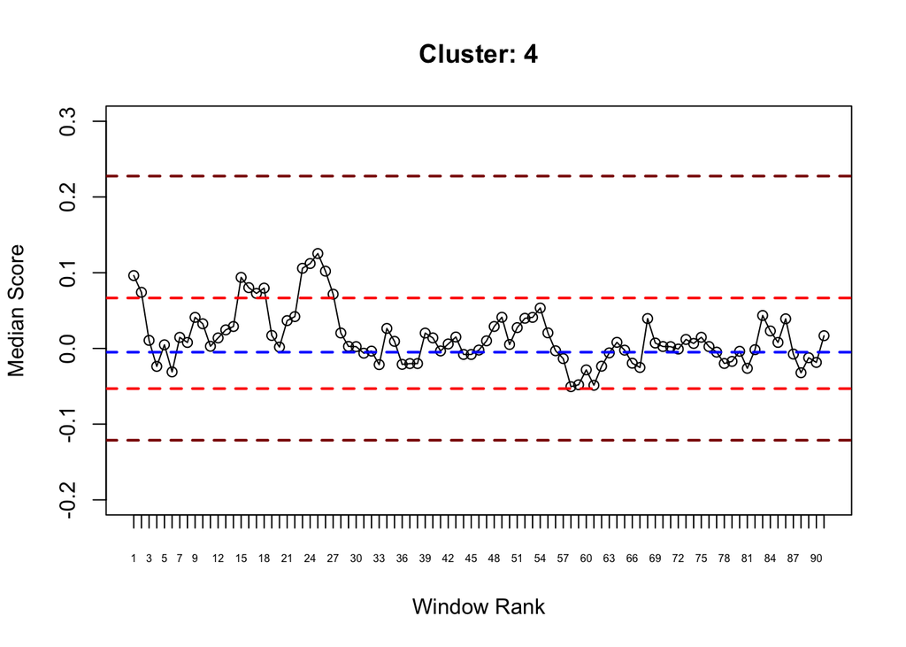

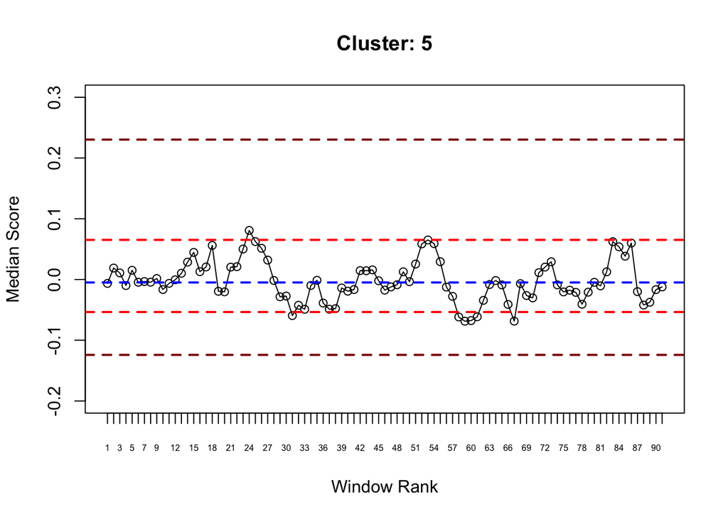

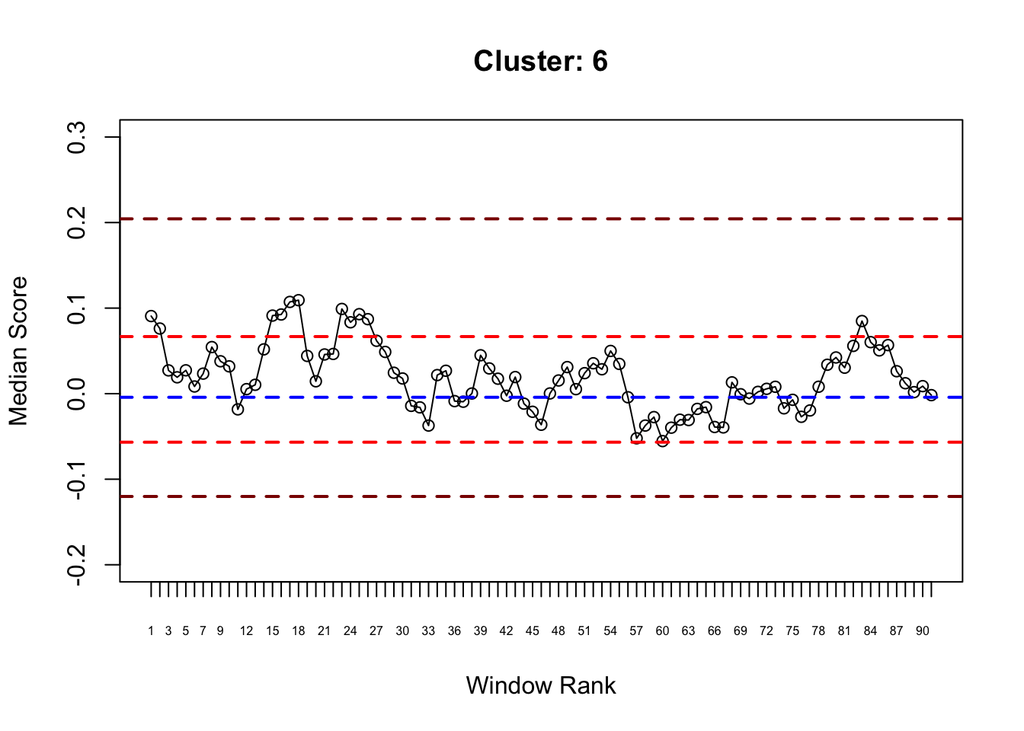

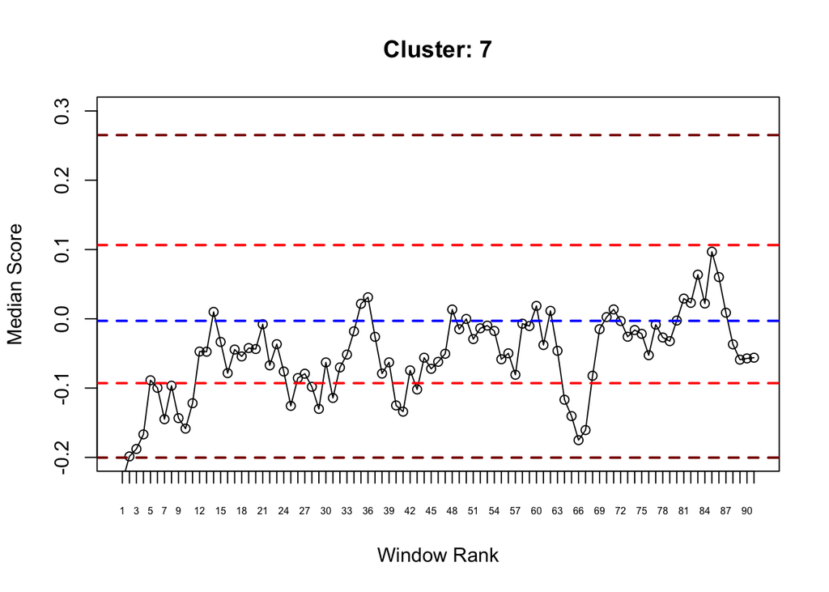

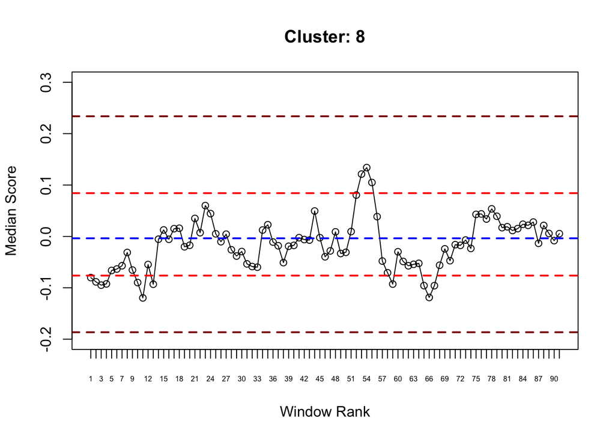

```r
 rank_plot_for_clusters(
   window_results = window_results.g,
   perm.mat.window = perm.mat.window.data,
   ylim = c(-0.2, 0.3)
 )
```

# 5 Fisher’s exact test

Load DEGs data.

```r
DEG_genes <- read_csv2("data/human_brain_cortex/DEG_output/DE_genes.csv")
```

```
## ℹ Using "','" as decimal and "'.'" as grouping mark. Use `read_delim()` for more control.
```

```r
DEG_genes <- as.data.frame(DEG_genes)
DEG_genes$p_val_adj <- as.numeric(DEG_genes$p_val_adj)
DEG_genes <- subset(DEG_genes, subset = p_val_adj <= 0.05) # using only significant DEG
```

Subset to select the top ranked genes.

```r
OpenTargets_SCZ_Genetic_top <- OpenTargets_SCZ_Genetic_[1:310]
length(OpenTargets_SCZ_Genetic_top)
```

```
## [1] 310
```

Run Fisher’s exact test. Structure 8 is excluded here due to having no significant DEGs.

```r
fisher_results_top_genes <- run_fisher_test_degs(se, DEG_genes = DEG_genes, OT_genes = OpenTargets_SCZ_Genetic_top)
fisher_results_top_genes
```

```
##   cluster      p_value odds_ratio  adj_p_value
## 1       0 1.454650e-01  1.8545884 1.000000e+00
## 2       1 5.353724e-01  1.0720517 1.000000e+00
## 3       2 1.247825e-06  3.1440439 9.982601e-06
## 4       3 9.560411e-01  0.6403540 1.000000e+00
## 5       4 1.614781e-01  2.2439628 1.000000e+00
## 6       5 6.600171e-01  0.9396234 1.000000e+00
## 7       6 2.800586e-02  2.5090808 2.240469e-01
## 8       7 9.371064e-01  0.6606324 1.000000e+00
```

Plot results.

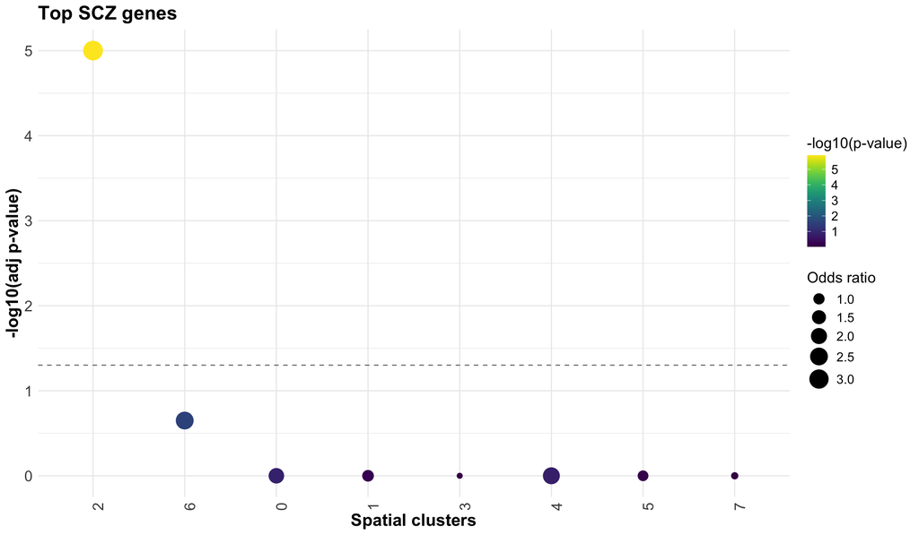

```r
# Ensure clusters are ordered by significance
fisher_results_top_genes$cluster <- factor(fisher_results_top_genes$cluster,
                                 levels = fisher_results_top_genes$cluster[order(fisher_results_top_genes$adj_p_value)])

# Create the updated plot with viridis scale
p1 <- ggplot(fisher_results_top_genes, aes(x = cluster, color = -log10(p_value), y = -log10(adj_p_value), size = odds_ratio)) +
  geom_point() +
  geom_hline(yintercept = -log10(0.05), linetype = "dashed", color = "gray50") +
  scale_color_viridis(option = "D", direction = 1, name = "-log10(p-value)") +  # Use Viridis color scale
  scale_size_continuous(range = c(2, 8), name = "Odds ratio") +
  theme_minimal() +
  theme(axis.text.x = element_text(angle = 90, hjust = 1,size = 14),axis.text.y = element_text(size = 14),axis.title.x = element_text(size = 16, face = "bold"),axis.title.y = element_text(size = 16, face = "bold"),plot.title = element_text(size = 18, face = "bold"),legend.title = element_text(size = 14),legend.text = element_text(size = 12)) +
  labs(title = "Top SCZ genes",
       x = "Spatial clusters",
       y = "-log10(adj p-value)") +
  guides(color = guide_colorbar(order = 1), size = guide_legend(order = 2))

p1
```

PDF

```r
pdf(file = "data/human_brain_cortex/STEAM_plots/fishers_exact_test_DEGup_topSTEAM_SCZ.pdf", height = 7, width = 12)

p1

dev.off()
```

Run Fisher’s exact test.

```r
fisher_results <- run_fisher_test_degs(se, DEG_genes = DEG_genes, OT_genes = OpenTargets_SCZ_Genetic_)
fisher_results
```

```
##   cluster      p_value odds_ratio adj_p_value
## 1       0 0.1491249509  1.4546325 1.000000000
## 2       1 0.7755014129  0.7908945 1.000000000
## 3       2 0.0001764307  1.8367700 0.001411445
## 4       3 0.9960582042  0.6611365 1.000000000
## 5       4 0.6332022173  0.9245880 1.000000000
## 6       5 0.9679042798  0.2852625 1.000000000
## 7       6 0.1209102571  1.4937616 0.967282057
## 8       7 0.9312377209  0.7955625 1.000000000
```

Plot results.

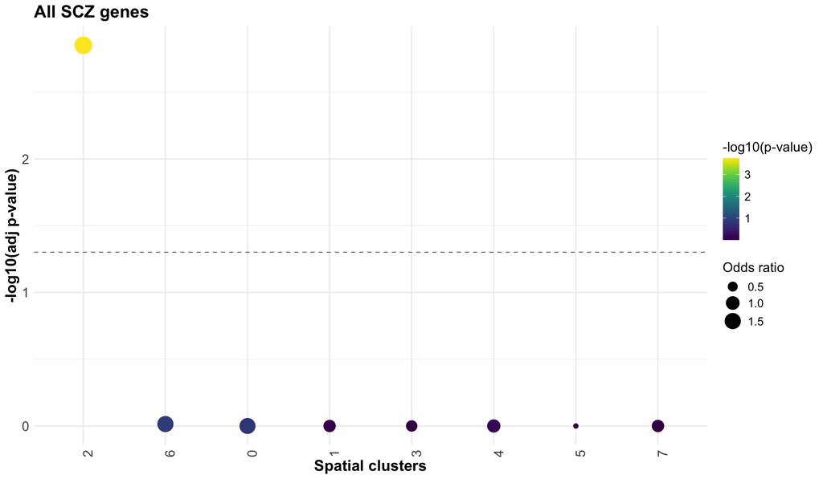

```r
# Ensure clusters are ordered by significance
fisher_results$cluster <- factor(fisher_results$cluster,
                                 levels = fisher_results$cluster[order(fisher_results$adj_p_value)])

# Create the updated plot with viridis scale
p2 <- ggplot(fisher_results, aes(x = cluster, color = -log10(p_value), y = -log10(adj_p_value), size = odds_ratio)) +
  geom_point() +
  geom_hline(yintercept = -log10(0.05), linetype = "dashed", color = "gray50") +
  scale_color_viridis(option = "D", direction = 1, name = "-log10(p-value)") +  # Use Viridis color scale
  scale_size_continuous(range = c(2, 8), name = "Odds ratio") +
  theme_minimal() +
  theme(axis.text.x = element_text(angle = 90, hjust = 1,size = 14),axis.text.y = element_text(size = 14),axis.title.x = element_text(size = 16, face = "bold"),axis.title.y = element_text(size = 16, face = "bold"),plot.title = element_text(size = 18, face = "bold"),legend.title = element_text(size = 14),legend.text = element_text(size = 12)) +
  labs(title = "All SCZ genes",
       x = "Spatial clusters",
       y = "-log10(adj p-value)") +
  guides(color = guide_colorbar(order = 1), size = guide_legend(order = 2))

p2
```

PDF

```r
pdf(file = "data/human_brain_cortex/STEAM_plots/fishers_exact_test_DEGup_all_SCZ.pdf", height = 7, width = 12)

p2

dev.off()
```

# 6 Plot spatial enrichments

Load data.

```r
se <- Load10X_Spatial(
  data.dir = "data/human_brain_cortex/",
  filename = "filtered_feature_bc_matrix.h5",
  assay = "Spatial",
  slice = "slice1"
)

se
```

```
## An object of class Seurat
## 33538 features across 3639 samples within 1 assay
## Active assay: Spatial (33538 features, 0 variable features)
##  1 layer present: counts
##  1 spatial field of view present: slice1
```

Filter data

```r
# Get raw count matrix
counts <- GetAssayData(se, slot = "counts")

# Apply gene filters
genes_to_keep <- rownames(counts)[
  Matrix::rowSums(counts) >= 100 &     # Total UMI count per gene
  Matrix::rowSums(counts > 0) >= 5     # Expressed in ≥5 spots
]

# Apply spot (cell) filters
spots_to_keep <- colnames(counts)[
  Matrix::colSums(counts) >= 500       # Total UMIs per spot
]

# Subset the Seurat object with filtered genes and spots
se <- subset(se, features = genes_to_keep, cells = spots_to_keep)
se
```

```
## An object of class Seurat
## 11381 features across 3632 samples within 1 assay
## Active assay: Spatial (11381 features, 0 variable features)
##  1 layer present: counts
##  1 spatial field of view present: slice1
```

Load cluster annotations.

```r
seurat_clusters <- read.csv(file = "data/human_brain_cortex/seurat_clusters.csv", sep = ";")
```

Check cluster annotations and Seurat object barcode names.

```r
head(seurat_clusters)
```

```
##                Barcode seurat_clusters
## 1 TTATTTCATCCCAAAC-1_1               5
## 2 GAGCGCTATGTCAGGC-1_1               5
## 3 CTTCGTGCCCGCATCG-1_1               5
## 4 GACGGGATGTCTTATG-1_1               5
## 5 GGCGAGCATCGAGGAC-1_1               5
## 6 CGCGTGCTATCAACGA-1_1               5
```

```r
head(se[[]])
```

```
##                       orig.ident nCount_Spatial nFeature_Spatial
## AAACAAGTATCTCCCA-1 SeuratProject           8458             3586
## AAACAATCTACTAGCA-1 SeuratProject           1667             1150
## AAACACCAATAACTGC-1 SeuratProject           3769             1960
## AAACAGAGCGACTCCT-1 SeuratProject           5433             2424
## AAACAGCTTTCAGAAG-1 SeuratProject           4278             2264
## AAACAGGGTCTATATT-1 SeuratProject           4004             2178
```

Update cluster annotations to match the Seurat objects barcodes.

```r
seurat_clusters$Barcode <- sub("_1$", "", seurat_clusters$Barcode)
head(seurat_clusters)
```

```
##              Barcode seurat_clusters
## 1 TTATTTCATCCCAAAC-1               5
## 2 GAGCGCTATGTCAGGC-1               5
## 3 CTTCGTGCCCGCATCG-1               5
## 4 GACGGGATGTCTTATG-1               5
## 5 GGCGAGCATCGAGGAC-1               5
## 6 CGCGTGCTATCAACGA-1               5
```

Add annotations to seurat object

```r
rownames(seurat_clusters) <- seurat_clusters$Barcode
seurat_clusters$Barcode <- NULL
se$seurat_clusters <- seurat_clusters
se$seurat_clusters_plot <- as.factor(se$seurat_clusters) # For plotting of spatial structures
head(se[[]])
```

```
##                       orig.ident nCount_Spatial nFeature_Spatial
## AAACAAGTATCTCCCA-1 SeuratProject           8458             3586
## AAACAATCTACTAGCA-1 SeuratProject           1667             1150
## AAACACCAATAACTGC-1 SeuratProject           3769             1960
## AAACAGAGCGACTCCT-1 SeuratProject           5433             2424
## AAACAGCTTTCAGAAG-1 SeuratProject           4278             2264
## AAACAGGGTCTATATT-1 SeuratProject           4004             2178
##                    seurat_clusters seurat_clusters_plot
## AAACAAGTATCTCCCA-1               4                    4
## AAACAATCTACTAGCA-1               5                    5
## AAACACCAATAACTGC-1               7                    7
## AAACAGAGCGACTCCT-1               2                    2
## AAACAGCTTTCAGAAG-1               8                    8
## AAACAGGGTCTATATT-1               3                    3
```

Plot seurat_clusters

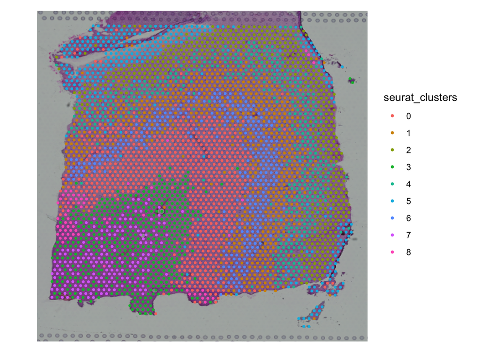

```r
SpatialDimPlot(se,group.by = "seurat_clusters")
```

```r
# Ensure cluster column is character or factor
fisher_results_top_genes$cluster <- as.character(fisher_results_top_genes$cluster)

# Add missing cluster 8 with NA values
all_clusters <- as.character(0:8)
fisher_results_top_genes_full <- merge(
  data.frame(cluster = all_clusters),
  fisher_results_top_genes,
  by = "cluster",
  all.x = TRUE
)

# Convert cluster to factor to match Seurat metadata
fisher_results_top_genes_full$cluster <- factor(fisher_results_top_genes_full$cluster, levels = all_clusters)

# Create a data frame for metadata mapping
meta_to_add <- fisher_results_top_genes_full[, c("cluster", "p_value", "odds_ratio", "adj_p_value")]

# Map metadata to each cell in the Seurat object
cluster_ids <- as.character(se$seurat_clusters)
meta_matched <- meta_to_add[match(cluster_ids, meta_to_add$cluster), -1]

# Add the metadata columns to the Seurat object
se$p_value_fisher <- meta_matched$p_value
se$odds_ratio_fisher <- meta_matched$odds_ratio
se$adj_p_value_fisher <- meta_matched$adj_p_value

# Compute -log10(p_value) and add as metadata
se$neg.log.10.p_value_fisher <- -log10(meta_matched$p_value)
se$neg.log.10.p_value_fisher[is.infinite(meta_matched$neg.log.10.p_value_fisher)] <- NA
se$neg.log.10.adj_p_value_fisher <- -log10(meta_matched$adj_p_value)
se$neg.log.10.adj_p_value_fisher[is.infinite(meta_matched$neg.log.10.adj_p_value_fisher)] <- NA
```

Plot the adjusted p-values

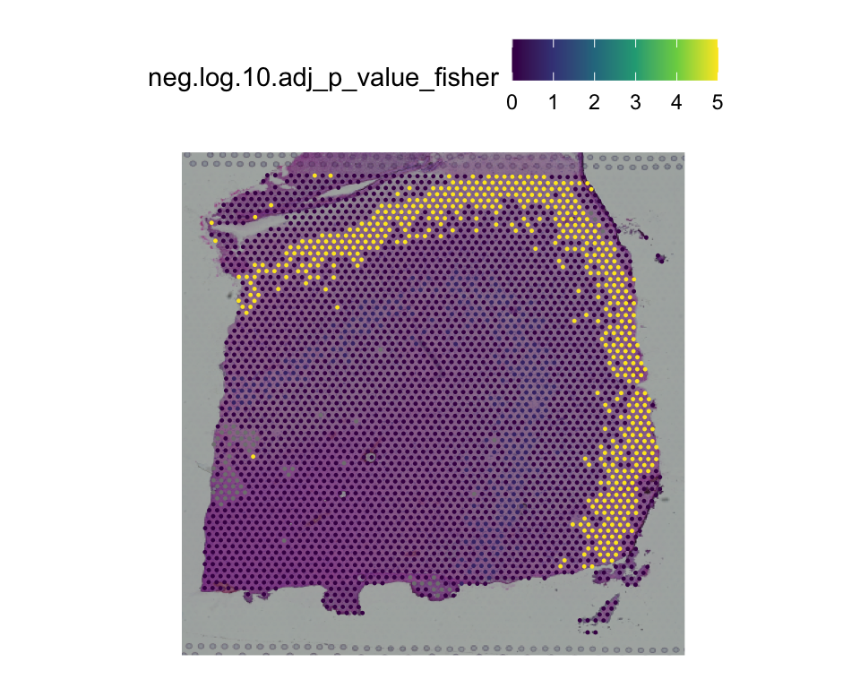

```r
p3 <- SpatialFeaturePlot(se,features = "neg.log.10.adj_p_value_fisher") + scale_fill_viridis_c()
p3
```

PDF

```r
pdf(file = "data/human_brain_cortex/STEAM_plots/spatial_fisher_results_top_genes_SCZ.pdf", height = 4, width = 5)

p3

dev.off()
```